# Risk Factor Analysis

## Outcome Variable

**Outcome Variable:** whz

## Predictor Variables

**Intervention Variable:** perdiar24

**Adjustment Set:**

- arm
- sex
- meducyrs
- feducyrs
- hhwealth_quart
- hfoodsec
- vagbrth
- hdlvry
- W_birthwt
- W_birthlen
- single
- W_nrooms
- month
- brthmon
- impfloor
- impsan
- safeh20
- delta_meducyrs
- delta_feducyrs
- delta_hhwealth_quart
- delta_hfoodsec
- delta_vagbrth
- delta_hdlvry
- delta_W_birthwt
- delta_W_birthlen
- delta_single
- delta_W_nrooms
- delta_month
- delta_brthmon
- delta_impfloor
- delta_impsan
- delta_safeh20

## Stratifying Variables

The analysis was stratified on these variable(s):

- agecat
- studyid
- country

## Data Summary

| agecat | studyid | country | perdiar24 | n_cell | n | outcome_variable |
| --- | --- | --- | --- | --- | --- | --- |
| Birth | CMIN | BANGLADESH | 0% | 6 | 19 | whz |
| Birth | CMIN | BANGLADESH | (0%, 5%] | 3 | 19 | whz |
| Birth | CMIN | BANGLADESH | >5% | 10 | 19 | whz |
| Birth | CONTENT | PERU | 0% | 0 | 2 | whz |
| Birth | CONTENT | PERU | (0%, 5%] | 1 | 2 | whz |
| Birth | CONTENT | PERU | >5% | 1 | 2 | whz |
| Birth | EE | PAKISTAN | 0% | 115 | 177 | whz |
| Birth | EE | PAKISTAN | (0%, 5%] | 62 | 177 | whz |
| Birth | EE | PAKISTAN | >5% | 0 | 177 | whz |
| Birth | JiVitA-4 | BANGLADESH | 0% | 61 | 2396 | whz |
| Birth | JiVitA-4 | BANGLADESH | (0%, 5%] | 2091 | 2396 | whz |
| Birth | JiVitA-4 | BANGLADESH | >5% | 244 | 2396 | whz |
| Birth | MAL-ED | BANGLADESH | 0% | 14 | 215 | whz |
| Birth | MAL-ED | BANGLADESH | (0%, 5%] | 127 | 215 | whz |
| Birth | MAL-ED | BANGLADESH | >5% | 74 | 215 | whz |
| Birth | MAL-ED | BRAZIL | 0% | 34 | 62 | whz |
| Birth | MAL-ED | BRAZIL | (0%, 5%] | 26 | 62 | whz |
| Birth | MAL-ED | BRAZIL | >5% | 2 | 62 | whz |
| Birth | MAL-ED | INDIA | 0% | 5 | 45 | whz |
| Birth | MAL-ED | INDIA | (0%, 5%] | 31 | 45 | whz |
| Birth | MAL-ED | INDIA | >5% | 9 | 45 | whz |
| Birth | MAL-ED | NEPAL | 0% | 2 | 26 | whz |
| Birth | MAL-ED | NEPAL | (0%, 5%] | 19 | 26 | whz |
| Birth | MAL-ED | NEPAL | >5% | 5 | 26 | whz |
| Birth | MAL-ED | PERU | 0% | 21 | 228 | whz |
| Birth | MAL-ED | PERU | (0%, 5%] | 87 | 228 | whz |
| Birth | MAL-ED | PERU | >5% | 120 | 228 | whz |
| Birth | MAL-ED | SOUTH AFRICA | 0% | 42 | 112 | whz |
| Birth | MAL-ED | SOUTH AFRICA | (0%, 5%] | 69 | 112 | whz |
| Birth | MAL-ED | SOUTH AFRICA | >5% | 1 | 112 | whz |

[output cut: 102 more lines]

The following strata were considered:

- agecat: 24 months, studyid: CMIN, country: BANGLADESH
- agecat: 24 months, studyid: CONTENT, country: PERU
- agecat: 24 months, studyid: EE, country: PAKISTAN
- agecat: 24 months, studyid: JiVitA-4, country: BANGLADESH
- agecat: 24 months, studyid: MAL-ED, country: BANGLADESH
- agecat: 24 months, studyid: MAL-ED, country: BRAZIL
- agecat: 24 months, studyid: MAL-ED, country: INDIA
- agecat: 24 months, studyid: MAL-ED, country: NEPAL
- agecat: 24 months, studyid: MAL-ED, country: PERU
- agecat: 24 months, studyid: MAL-ED, country: SOUTH AFRICA
- agecat: 24 months, studyid: MAL-ED, country: TANZANIA, UNITED REPUBLIC OF
- agecat: 24 months, studyid: NIH-Birth, country: BANGLADESH
- agecat: 24 months, studyid: NIH-Crypto, country: BANGLADESH
- agecat: 24 months, studyid: PROVIDE, country: BANGLADESH
- agecat: 6 months, studyid: CMIN, country: BANGLADESH
- agecat: 6 months, studyid: CONTENT, country: PERU
- agecat: 6 months, studyid: EE, country: PAKISTAN
- agecat: 6 months, studyid: Guatemala BSC, country: GUATEMALA
- agecat: 6 months, studyid: JiVitA-4, country: BANGLADESH
- agecat: 6 months, studyid: MAL-ED, country: BANGLADESH
- agecat: 6 months, studyid: MAL-ED, country: BRAZIL
- agecat: 6 months, studyid: MAL-ED, country: INDIA
- agecat: 6 months, studyid: MAL-ED, country: NEPAL
- agecat: 6 months, studyid: MAL-ED, country: PERU
- agecat: 6 months, studyid: MAL-ED, country: SOUTH AFRICA
- agecat: 6 months, studyid: MAL-ED, country: TANZANIA, UNITED REPUBLIC OF
- agecat: 6 months, studyid: NIH-Birth, country: BANGLADESH
- agecat: 6 months, studyid: NIH-Crypto, country: BANGLADESH
- agecat: 6 months, studyid: PROVIDE, country: BANGLADESH
- agecat: 6 months, studyid: SAS-FoodSuppl, country: INDIA
- agecat: Birth, studyid: CMIN, country: BANGLADESH
- agecat: Birth, studyid: CONTENT, country: PERU
- agecat: Birth, studyid: EE, country: PAKISTAN
- agecat: Birth, studyid: JiVitA-4, country: BANGLADESH
- agecat: Birth, studyid: MAL-ED, country: BANGLADESH
- agecat: Birth, studyid: MAL-ED, country: BRAZIL
- agecat: Birth, studyid: MAL-ED, country: INDIA
- agecat: Birth, studyid: MAL-ED, country: NEPAL
- agecat: Birth, studyid: MAL-ED, country: PERU
- agecat: Birth, studyid: MAL-ED, country: SOUTH AFRICA
- agecat: Birth, studyid: MAL-ED, country: TANZANIA, UNITED REPUBLIC OF
- agecat: Birth, studyid: NIH-Birth, country: BANGLADESH
- agecat: Birth, studyid: NIH-Crypto, country: BANGLADESH
- agecat: Birth, studyid: PROVIDE, country: BANGLADESH

### Dropped Strata

Some strata were dropped due to rare outcomes:

- agecat: Birth, studyid: CMIN, country: BANGLADESH
- agecat: Birth, studyid: CONTENT, country: PERU
- agecat: Birth, studyid: EE, country: PAKISTAN
- agecat: Birth, studyid: MAL-ED, country: BRAZIL
- agecat: Birth, studyid: MAL-ED, country: NEPAL
- agecat: Birth, studyid: MAL-ED, country: SOUTH AFRICA
- agecat: 6 months, studyid: CMIN, country: BANGLADESH
- agecat: 6 months, studyid: EE, country: PAKISTAN
- agecat: 6 months, studyid: MAL-ED, country: BRAZIL
- agecat: 6 months, studyid: MAL-ED, country: INDIA
- agecat: 6 months, studyid: MAL-ED, country: SOUTH AFRICA
- agecat: 24 months, studyid: CMIN, country: BANGLADESH
- agecat: 24 months, studyid: CONTENT, country: PERU
- agecat: 24 months, studyid: EE, country: PAKISTAN
- agecat: 24 months, studyid: MAL-ED, country: BRAZIL
- agecat: 24 months, studyid: MAL-ED, country: INDIA
- agecat: 24 months, studyid: MAL-ED, country: PERU
- agecat: 24 months, studyid: MAL-ED, country: SOUTH AFRICA

## Methods Detail

We’re interested in the causal parameters $E[Y_a]$ for all values of $a \in \mathcal{A}$. These parameters represent the mean outcome if, possibly contrary to fact, we intervened to set all units to have $A=a$. Under the randomization and positivity assumptions, these are identified by the statistical parameters $\psi_a=E_W[E_{Y|A,W}(Y|A=a,W)]$. In addition, we’re interested in the mean of $Y$, $E[Y]$ under no intervention (the observed mean). We will estimate these parameters by using SuperLearner to fit the relevant likelihood factors – $E_{Y|A,W}(Y|A=a,W)$ and $p(A=a|W)$, and then updating our likelihood fit using a joint TMLE.

For unadjusted analyses ($W=\{\}$), initial likelihoods were estimated using Lrnr_glm to estimate the simple $E(Y|A)$ and Lrnr_mean to estimate $p(A)$. For adjusted analyses, a small library containing Lrnr_glmnet, Lrnr_xgboost, and Lrnr_mean was used.

Having estimated these parameters, we will then use the delta method to estimate relative risks and attributable risks relative to a prespecified baseline level of $A$.

# Results Detail

## Results Plots

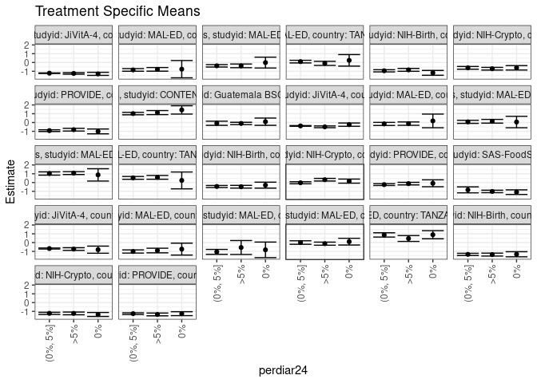

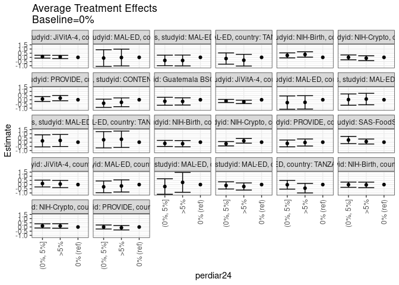

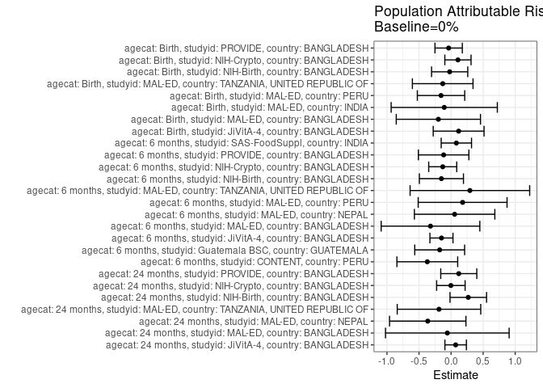

## Results Table

### Parameter: TSM

| agecat | studyid | country | intervention_level | baseline_level | estimate | ci_lower | ci_upper |
| --- | --- | --- | --- | --- | --- | --- | --- |
| Birth | JiVitA-4 | BANGLADESH | 0% | NA | -0.8064749 | -1.2123112 | -0.4006385 |
| Birth | JiVitA-4 | BANGLADESH | (0%, 5%] | NA | -0.6789099 | -0.7346217 | -0.6231980 |
| Birth | JiVitA-4 | BANGLADESH | >5% | NA | -0.7372359 | -0.8872072 | -0.5872646 |
| Birth | MAL-ED | BANGLADESH | 0% | NA | -0.7437696 | -1.4215486 | -0.0659907 |
| Birth | MAL-ED | BANGLADESH | (0%, 5%] | NA | -1.0133673 | -1.1962882 | -0.8304463 |
| Birth | MAL-ED | BANGLADESH | >5% | NA | -0.9064378 | -1.1690382 | -0.6438374 |
| Birth | MAL-ED | INDIA | 0% | NA | -0.8260000 | -1.7120476 | 0.0600476 |
| Birth | MAL-ED | INDIA | (0%, 5%] | NA | -1.0574194 | -1.3366625 | -0.7781762 |
| Birth | MAL-ED | INDIA | >5% | NA | -0.5611111 | -1.3534381 | 0.2312159 |
| Birth | MAL-ED | PERU | 0% | NA | 0.1045894 | -0.2774880 | 0.4866669 |
| Birth | MAL-ED | PERU | (0%, 5%] | NA | 0.0053194 | -0.1934964 | 0.2041353 |
| Birth | MAL-ED | PERU | >5% | NA | -0.1235964 | -0.2986086 | 0.0514159 |
| Birth | MAL-ED | TANZANIA, UNITED REPUBLIC OF | 0% | NA | 0.8928571 | 0.4313181 | 1.3543962 |
| Birth | MAL-ED | TANZANIA, UNITED REPUBLIC OF | (0%, 5%] | NA | 0.8712987 | 0.6273536 | 1.1152438 |
| Birth | MAL-ED | TANZANIA, UNITED REPUBLIC OF | >5% | NA | 0.4625806 | 0.1300967 | 0.7950646 |
| Birth | NIH-Birth | BANGLADESH | 0% | NA | -1.3305876 | -1.6210687 | -1.0401065 |
| Birth | NIH-Birth | BANGLADESH | (0%, 5%] | NA | -1.3442512 | -1.4706745 | -1.2178279 |
| Birth | NIH-Birth | BANGLADESH | >5% | NA | -1.3662650 | -1.5326315 | -1.1998986 |
| Birth | NIH-Crypto | BANGLADESH | 0% | NA | -1.3512419 | -1.5775637 | -1.1249200 |
| Birth | NIH-Crypto | BANGLADESH | (0%, 5%] | NA | -1.2211464 | -1.3412917 | -1.1010012 |
| Birth | NIH-Crypto | BANGLADESH | >5% | NA | -1.2286545 | -1.3825683 | -1.0747408 |
| Birth | PROVIDE | BANGLADESH | 0% | NA | -1.2604999 | -1.4828620 | -1.0381377 |
| Birth | PROVIDE | BANGLADESH | (0%, 5%] | NA | -1.2593179 | -1.3542945 | -1.1643414 |
| Birth | PROVIDE | BANGLADESH | >5% | NA | -1.3468684 | -1.5034940 | -1.1902428 |
| 6 months | CONTENT | PERU | 0% | NA | 1.4351667 | 0.9626985 | 1.9076349 |
| 6 months | CONTENT | PERU | (0%, 5%] | NA | 1.0176514 | 0.8796884 | 1.1556144 |
| 6 months | CONTENT | PERU | >5% | NA | 1.1303657 | 0.8984202 | 1.3623112 |
| 6 months | Guatemala BSC | GUATEMALA | 0% | NA | 0.0936689 | -0.3198745 | 0.5072123 |
| 6 months | Guatemala BSC | GUATEMALA | (0%, 5%] | NA | -0.0847957 | -0.3208686 | 0.1512772 |
| 6 months | Guatemala BSC | GUATEMALA | >5% | NA | -0.1066520 | -0.2378985 | 0.0245945 |
| 6 months | JiVitA-4 | BANGLADESH | 0% | NA | -0.2397416 | -0.4243047 | -0.0551785 |
| 6 months | JiVitA-4 | BANGLADESH | (0%, 5%] | NA | -0.3848494 | -0.4237666 | -0.3459323 |
| 6 months | JiVitA-4 | BANGLADESH | >5% | NA | -0.4907081 | -0.5898527 | -0.3915634 |
| 6 months | MAL-ED | BANGLADESH | 0% | NA | 0.1833333 | -0.5948965 | 0.9615632 |
| 6 months | MAL-ED | BANGLADESH | (0%, 5%] | NA | -0.1581455 | -0.3337303 | 0.0174392 |
| 6 months | MAL-ED | BANGLADESH | >5% | NA | -0.1271326 | -0.3185947 | 0.0643295 |
| 6 months | MAL-ED | NEPAL | 0% | NA | 0.0552790 | -0.5972282 | 0.7077861 |
| 6 months | MAL-ED | NEPAL | (0%, 5%] | NA | 0.0778427 | -0.0963077 | 0.2519932 |
| 6 months | MAL-ED | NEPAL | >5% | NA | 0.1415191 | -0.0719267 | 0.3549649 |
| 6 months | MAL-ED | PERU | 0% | NA | 0.8728571 | 0.1723061 | 1.5734082 |
| 6 months | MAL-ED | PERU | (0%, 5%] | NA | 1.0295260 | 0.8447495 | 1.2143025 |
| 6 months | MAL-ED | PERU | >5% | NA | 1.0771231 | 0.9121893 | 1.2420570 |
| 6 months | MAL-ED | TANZANIA, UNITED REPUBLIC OF | 0% | NA | 0.2427778 | -0.7161220 | 1.2016775 |
| 6 months | MAL-ED | TANZANIA, UNITED REPUBLIC OF | (0%, 5%] | NA | 0.5318644 | 0.3720281 | 0.6917007 |
| 6 months | MAL-ED | TANZANIA, UNITED REPUBLIC OF | >5% | NA | 0.5921585 | 0.3766024 | 0.8077146 |
| 6 months | NIH-Birth | BANGLADESH | 0% | NA | -0.2966400 | -0.6375441 | 0.0442642 |
| 6 months | NIH-Birth | BANGLADESH | (0%, 5%] | NA | -0.4488847 | -0.5664777 | -0.3312916 |
| 6 months | NIH-Birth | BANGLADESH | >5% | NA | -0.4794778 | -0.6355266 | -0.3234290 |
| 6 months | NIH-Crypto | BANGLADESH | 0% | NA | 0.1599836 | -0.0732228 | 0.3931900 |
| 6 months | NIH-Crypto | BANGLADESH | (0%, 5%] | NA | -0.0266269 | -0.1409639 | 0.0877101 |
| 6 months | NIH-Crypto | BANGLADESH | >5% | NA | 0.3215490 | 0.1728072 | 0.4702908 |
| 6 months | PROVIDE | BANGLADESH | 0% | NA | -0.0830904 | -0.4771648 | 0.3109840 |
| 6 months | PROVIDE | BANGLADESH | (0%, 5%] | NA | -0.2357832 | -0.3383637 | -0.1332026 |
| 6 months | PROVIDE | BANGLADESH | >5% | NA | -0.1234510 | -0.2695224 | 0.0226204 |
| 6 months | SAS-FoodSuppl | INDIA | 0% | NA | -1.0946546 | -1.3570916 | -0.8322176 |
| 6 months | SAS-FoodSuppl | INDIA | (0%, 5%] | NA | -0.8341234 | -1.1753064 | -0.4929403 |
| 6 months | SAS-FoodSuppl | INDIA | >5% | NA | -1.0155176 | -1.1561450 | -0.8748903 |
| 24 months | JiVitA-4 | BANGLADESH | 0% | NA | -1.2944363 | -1.4679420 | -1.1209306 |
| 24 months | JiVitA-4 | BANGLADESH | (0%, 5%] | NA | -1.2182980 | -1.2511684 | -1.1854276 |
| 24 months | JiVitA-4 | BANGLADESH | >5% | NA | -1.2477701 | -1.3370525 | -1.1584878 |
| 24 months | MAL-ED | BANGLADESH | 0% | NA | -0.7608333 | -1.7455859 | 0.2239193 |
| 24 months | MAL-ED | BANGLADESH | (0%, 5%] | NA | -0.8440769 | -0.9945327 | -0.6936211 |
| 24 months | MAL-ED | BANGLADESH | >5% | NA | -0.7815132 | -0.9897171 | -0.5733093 |
| 24 months | MAL-ED | NEPAL | 0% | NA | -0.0107432 | -0.6269770 | 0.6054906 |
| 24 months | MAL-ED | NEPAL | (0%, 5%] | NA | -0.3784191 | -0.5172129 | -0.2396253 |
| 24 months | MAL-ED | NEPAL | >5% | NA | -0.3843468 | -0.5924805 | -0.1762132 |
| 24 months | MAL-ED | TANZANIA, UNITED REPUBLIC OF | 0% | NA | 0.2433333 | -0.4146176 | 0.9012843 |
| 24 months | MAL-ED | TANZANIA, UNITED REPUBLIC OF | (0%, 5%] | NA | 0.0989530 | -0.0508664 | 0.2487724 |
| 24 months | MAL-ED | TANZANIA, UNITED REPUBLIC OF | >5% | NA | -0.0994231 | -0.3337823 | 0.1349362 |
| 24 months | NIH-Birth | BANGLADESH | 0% | NA | -1.1800000 | -1.4547770 | -0.9052230 |
| 24 months | NIH-Birth | BANGLADESH | (0%, 5%] | NA | -0.9456415 | -1.0692081 | -0.8220748 |
| 24 months | NIH-Birth | BANGLADESH | >5% | NA | -0.8370172 | -1.0005302 | -0.6735043 |
| 24 months | NIH-Crypto | BANGLADESH | 0% | NA | -0.6073006 | -0.8573238 | -0.3572775 |
| 24 months | NIH-Crypto | BANGLADESH | (0%, 5%] | NA | -0.6103478 | -0.7643595 | -0.4563361 |
| 24 months | NIH-Crypto | BANGLADESH | >5% | NA | -0.7099077 | -0.8608731 | -0.5589423 |
| 24 months | PROVIDE | BANGLADESH | 0% | NA | -1.0127778 | -1.2883897 | -0.7371658 |
| 24 months | PROVIDE | BANGLADESH | (0%, 5%] | NA | -0.9233081 | -1.0226788 | -0.8239373 |
| 24 months | PROVIDE | BANGLADESH | >5% | NA | -0.8173851 | -0.9715768 | -0.6631933 |

### Parameter: E(Y)

| agecat | studyid | country | intervention_level | baseline_level | estimate | ci_lower | ci_upper |
| --- | --- | --- | --- | --- | --- | --- | --- |
| Birth | JiVitA-4 | BANGLADESH | NA | NA | -0.6886269 | -0.7410452 | -0.6362086 |
| Birth | MAL-ED | BANGLADESH | NA | NA | -0.9418605 | -1.0869834 | -0.7967375 |
| Birth | MAL-ED | INDIA | NA | NA | -0.9324444 | -1.2067907 | -0.6580982 |
| Birth | MAL-ED | PERU | NA | NA | -0.0520175 | -0.1725298 | 0.0684947 |
| Birth | MAL-ED | TANZANIA, UNITED REPUBLIC OF | NA | NA | 0.7624348 | 0.5710709 | 0.9537986 |
| Birth | NIH-Birth | BANGLADESH | NA | NA | -1.3525437 | -1.4473932 | -1.2576942 |
| Birth | NIH-Crypto | BANGLADESH | NA | NA | -1.2441513 | -1.3281130 | -1.1601897 |
| Birth | PROVIDE | BANGLADESH | NA | NA | -1.2984586 | -1.3752758 | -1.2216415 |
| 6 months | CONTENT | PERU | NA | NA | 1.0644279 | 0.9468682 | 1.1819876 |
| 6 months | Guatemala BSC | GUATEMALA | NA | NA | -0.0840134 | -0.1945572 | 0.0265305 |
| 6 months | JiVitA-4 | BANGLADESH | NA | NA | -0.3898055 | -0.4270507 | -0.3525603 |
| 6 months | MAL-ED | BANGLADESH | NA | NA | -0.1376763 | -0.2664642 | -0.0088885 |
| 6 months | MAL-ED | NEPAL | NA | NA | 0.1104308 | -0.0208643 | 0.2417259 |
| 6 months | MAL-ED | PERU | NA | NA | 1.0528816 | 0.9313005 | 1.1744626 |
| 6 months | MAL-ED | TANZANIA, UNITED REPUBLIC OF | NA | NA | 0.5362213 | 0.4049390 | 0.6675036 |
| 6 months | NIH-Birth | BANGLADESH | NA | NA | -0.4474038 | -0.5378167 | -0.3569909 |
| 6 months | NIH-Crypto | BANGLADESH | NA | NA | 0.0297622 | -0.0491685 | 0.1086930 |
| 6 months | PROVIDE | BANGLADESH | NA | NA | -0.1990907 | -0.2817968 | -0.1163845 |
| 6 months | SAS-FoodSuppl | INDIA | NA | NA | -1.0121579 | -1.1280429 | -0.8962729 |
| 24 months | JiVitA-4 | BANGLADESH | NA | NA | -1.2231088 | -1.2549632 | -1.1912543 |
| 24 months | MAL-ED | BANGLADESH | NA | NA | -0.8192925 | -0.9412667 | -0.6973182 |
| 24 months | MAL-ED | NEPAL | NA | NA | -0.3749123 | -0.4886073 | -0.2612173 |
| 24 months | MAL-ED | TANZANIA, UNITED REPUBLIC OF | NA | NA | 0.0547975 | -0.0703378 | 0.1799328 |
| 24 months | NIH-Birth | BANGLADESH | NA | NA | -0.9115790 | -1.0095022 | -0.8136559 |
| 24 months | NIH-Crypto | BANGLADESH | NA | NA | -0.6103502 | -0.7050157 | -0.5156847 |
| 24 months | PROVIDE | BANGLADESH | NA | NA | -0.8928670 | -0.9755153 | -0.8102187 |

### Parameter: ATE

| agecat | studyid | country | intervention_level | baseline_level | estimate | ci_lower | ci_upper |
| --- | --- | --- | --- | --- | --- | --- | --- |
| Birth | JiVitA-4 | BANGLADESH | 0% | 0% | 0.0000000 | 0.0000000 | 0.0000000 |
| Birth | JiVitA-4 | BANGLADESH | (0%, 5%] | 0% | 0.1275650 | -0.2796481 | 0.5347781 |
| Birth | JiVitA-4 | BANGLADESH | >5% | 0% | 0.0692390 | -0.3631647 | 0.5016428 |
| Birth | MAL-ED | BANGLADESH | 0% | 0% | 0.0000000 | 0.0000000 | 0.0000000 |
| Birth | MAL-ED | BANGLADESH | (0%, 5%] | 0% | -0.2695976 | -0.9721566 | 0.4329614 |
| Birth | MAL-ED | BANGLADESH | >5% | 0% | -0.1626681 | -0.8900641 | 0.5647278 |
| Birth | MAL-ED | INDIA | 0% | 0% | 0.0000000 | 0.0000000 | 0.0000000 |
| Birth | MAL-ED | INDIA | (0%, 5%] | 0% | -0.2314194 | -1.1604280 | 0.6975893 |
| Birth | MAL-ED | INDIA | >5% | 0% | 0.2648889 | -0.9237500 | 1.4535278 |
| Birth | MAL-ED | PERU | 0% | 0% | 0.0000000 | 0.0000000 | 0.0000000 |
| Birth | MAL-ED | PERU | (0%, 5%] | 0% | -0.0992700 | -0.5315054 | 0.3329654 |
| Birth | MAL-ED | PERU | >5% | 0% | -0.2281858 | -0.6527124 | 0.1963408 |
| Birth | MAL-ED | TANZANIA, UNITED REPUBLIC OF | 0% | 0% | 0.0000000 | 0.0000000 | 0.0000000 |
| Birth | MAL-ED | TANZANIA, UNITED REPUBLIC OF | (0%, 5%] | 0% | -0.0215584 | -0.5436001 | 0.5004833 |
| Birth | MAL-ED | TANZANIA, UNITED REPUBLIC OF | >5% | 0% | -0.4302765 | -0.9991033 | 0.1385503 |
| Birth | NIH-Birth | BANGLADESH | 0% | 0% | 0.0000000 | 0.0000000 | 0.0000000 |
| Birth | NIH-Birth | BANGLADESH | (0%, 5%] | 0% | -0.0136636 | -0.3282560 | 0.3009288 |
| Birth | NIH-Birth | BANGLADESH | >5% | 0% | -0.0356774 | -0.3690953 | 0.2977405 |
| Birth | NIH-Crypto | BANGLADESH | 0% | 0% | 0.0000000 | 0.0000000 | 0.0000000 |
| Birth | NIH-Crypto | BANGLADESH | (0%, 5%] | 0% | 0.1300954 | -0.1239072 | 0.3840980 |
| Birth | NIH-Crypto | BANGLADESH | >5% | 0% | 0.1225873 | -0.1490700 | 0.3942447 |
| Birth | PROVIDE | BANGLADESH | 0% | 0% | 0.0000000 | 0.0000000 | 0.0000000 |
| Birth | PROVIDE | BANGLADESH | (0%, 5%] | 0% | 0.0011819 | -0.2373772 | 0.2397410 |
| Birth | PROVIDE | BANGLADESH | >5% | 0% | -0.0863685 | -0.3548659 | 0.1821288 |
| 6 months | CONTENT | PERU | 0% | 0% | 0.0000000 | 0.0000000 | 0.0000000 |
| 6 months | CONTENT | PERU | (0%, 5%] | 0% | -0.4175153 | -0.9097144 | 0.0746839 |
| 6 months | CONTENT | PERU | >5% | 0% | -0.3048010 | -0.8311326 | 0.2215306 |
| 6 months | Guatemala BSC | GUATEMALA | 0% | 0% | 0.0000000 | 0.0000000 | 0.0000000 |
| 6 months | Guatemala BSC | GUATEMALA | (0%, 5%] | 0% | -0.1784646 | -0.6548348 | 0.2979056 |
| 6 months | Guatemala BSC | GUATEMALA | >5% | 0% | -0.2003209 | -0.6342268 | 0.2335850 |
| 6 months | JiVitA-4 | BANGLADESH | 0% | 0% | 0.0000000 | 0.0000000 | 0.0000000 |
| 6 months | JiVitA-4 | BANGLADESH | (0%, 5%] | 0% | -0.1451078 | -0.3308163 | 0.0406006 |
| 6 months | JiVitA-4 | BANGLADESH | >5% | 0% | -0.2509665 | -0.4543808 | -0.0475521 |
| 6 months | MAL-ED | BANGLADESH | 0% | 0% | 0.0000000 | 0.0000000 | 0.0000000 |
| 6 months | MAL-ED | BANGLADESH | (0%, 5%] | 0% | -0.3414789 | -1.1392706 | 0.4563129 |
| 6 months | MAL-ED | BANGLADESH | >5% | 0% | -0.3104659 | -1.1119018 | 0.4909699 |
| 6 months | MAL-ED | NEPAL | 0% | 0% | 0.0000000 | 0.0000000 | 0.0000000 |
| 6 months | MAL-ED | NEPAL | (0%, 5%] | 0% | 0.0225638 | -0.6522832 | 0.6974108 |
| 6 months | MAL-ED | NEPAL | >5% | 0% | 0.0862401 | -0.6006848 | 0.7731651 |
| 6 months | MAL-ED | PERU | 0% | 0% | 0.0000000 | 0.0000000 | 0.0000000 |
| 6 months | MAL-ED | PERU | (0%, 5%] | 0% | 0.1566689 | -0.5678407 | 0.8811784 |
| 6 months | MAL-ED | PERU | >5% | 0% | 0.2042660 | -0.5154387 | 0.9239707 |
| 6 months | MAL-ED | TANZANIA, UNITED REPUBLIC OF | 0% | 0% | 0.0000000 | 0.0000000 | 0.0000000 |
| 6 months | MAL-ED | TANZANIA, UNITED REPUBLIC OF | (0%, 5%] | 0% | 0.2890866 | -0.6830432 | 1.2612164 |
| 6 months | MAL-ED | TANZANIA, UNITED REPUBLIC OF | >5% | 0% | 0.3493807 | -0.6334485 | 1.3322099 |
| 6 months | NIH-Birth | BANGLADESH | 0% | 0% | 0.0000000 | 0.0000000 | 0.0000000 |
| 6 months | NIH-Birth | BANGLADESH | (0%, 5%] | 0% | -0.1522447 | -0.5133858 | 0.2088964 |
| 6 months | NIH-Birth | BANGLADESH | >5% | 0% | -0.1828379 | -0.5586617 | 0.1929860 |
| 6 months | NIH-Crypto | BANGLADESH | 0% | 0% | 0.0000000 | 0.0000000 | 0.0000000 |
| 6 months | NIH-Crypto | BANGLADESH | (0%, 5%] | 0% | -0.1866105 | -0.4461038 | 0.0728828 |
| 6 months | NIH-Crypto | BANGLADESH | >5% | 0% | 0.1615654 | -0.1159114 | 0.4390422 |
| 6 months | PROVIDE | BANGLADESH | 0% | 0% | 0.0000000 | 0.0000000 | 0.0000000 |
| 6 months | PROVIDE | BANGLADESH | (0%, 5%] | 0% | -0.1526928 | -0.5602498 | 0.2548642 |
| 6 months | PROVIDE | BANGLADESH | >5% | 0% | -0.0403607 | -0.4607010 | 0.3799796 |
| 6 months | SAS-FoodSuppl | INDIA | 0% | 0% | 0.0000000 | 0.0000000 | 0.0000000 |
| 6 months | SAS-FoodSuppl | INDIA | (0%, 5%] | 0% | 0.2605312 | -0.1701080 | 0.6911705 |
| 6 months | SAS-FoodSuppl | INDIA | >5% | 0% | 0.0791370 | -0.2186979 | 0.3769718 |
| 24 months | JiVitA-4 | BANGLADESH | 0% | 0% | 0.0000000 | 0.0000000 | 0.0000000 |
| 24 months | JiVitA-4 | BANGLADESH | (0%, 5%] | 0% | 0.0761383 | -0.0979566 | 0.2502332 |
| 24 months | JiVitA-4 | BANGLADESH | >5% | 0% | 0.0466662 | -0.1456094 | 0.2389417 |
| 24 months | MAL-ED | BANGLADESH | 0% | 0% | 0.0000000 | 0.0000000 | 0.0000000 |
| 24 months | MAL-ED | BANGLADESH | (0%, 5%] | 0% | -0.0832436 | -1.0794236 | 0.9129364 |
| 24 months | MAL-ED | BANGLADESH | >5% | 0% | -0.0206798 | -1.0272018 | 0.9858422 |
| 24 months | MAL-ED | NEPAL | 0% | 0% | 0.0000000 | 0.0000000 | 0.0000000 |
| 24 months | MAL-ED | NEPAL | (0%, 5%] | 0% | -0.3676759 | -0.9995119 | 0.2641600 |
| 24 months | MAL-ED | NEPAL | >5% | 0% | -0.3736036 | -1.0245666 | 0.2773593 |
| 24 months | MAL-ED | TANZANIA, UNITED REPUBLIC OF | 0% | 0% | 0.0000000 | 0.0000000 | 0.0000000 |
| 24 months | MAL-ED | TANZANIA, UNITED REPUBLIC OF | (0%, 5%] | 0% | -0.1443803 | -0.8191731 | 0.5304124 |
| 24 months | MAL-ED | TANZANIA, UNITED REPUBLIC OF | >5% | 0% | -0.3427564 | -1.0412002 | 0.3556873 |
| 24 months | NIH-Birth | BANGLADESH | 0% | 0% | 0.0000000 | 0.0000000 | 0.0000000 |
| 24 months | NIH-Birth | BANGLADESH | (0%, 5%] | 0% | 0.2343585 | -0.0669240 | 0.5356410 |
| 24 months | NIH-Birth | BANGLADESH | >5% | 0% | 0.3429828 | 0.0232346 | 0.6627310 |
| 24 months | NIH-Crypto | BANGLADESH | 0% | 0% | 0.0000000 | 0.0000000 | 0.0000000 |
| 24 months | NIH-Crypto | BANGLADESH | (0%, 5%] | 0% | -0.0030472 | -0.2949655 | 0.2888711 |
| 24 months | NIH-Crypto | BANGLADESH | >5% | 0% | -0.1026071 | -0.3941741 | 0.1889600 |
| 24 months | PROVIDE | BANGLADESH | 0% | 0% | 0.0000000 | 0.0000000 | 0.0000000 |
| 24 months | PROVIDE | BANGLADESH | (0%, 5%] | 0% | 0.0894697 | -0.2035090 | 0.3824484 |
| 24 months | PROVIDE | BANGLADESH | >5% | 0% | 0.1953927 | -0.1204190 | 0.5112044 |

### Parameter: PAR

| agecat | studyid | country | intervention_level | baseline_level | estimate | ci_lower | ci_upper |
| --- | --- | --- | --- | --- | --- | --- | --- |
| Birth | JiVitA-4 | BANGLADESH | 0% | NA | 0.1178480 | -0.2784685 | 0.5141645 |
| Birth | MAL-ED | BANGLADESH | 0% | NA | -0.1980908 | -0.8550326 | 0.4588510 |
| Birth | MAL-ED | INDIA | 0% | NA | -0.1064444 | -0.9346255 | 0.7217366 |
| Birth | MAL-ED | PERU | 0% | NA | -0.1566070 | -0.5261897 | 0.2129758 |
| Birth | MAL-ED | TANZANIA, UNITED REPUBLIC OF | 0% | NA | -0.1304224 | -0.6033978 | 0.3425531 |
| Birth | NIH-Birth | BANGLADESH | 0% | NA | -0.0219561 | -0.3041968 | 0.2602847 |
| Birth | NIH-Crypto | BANGLADESH | 0% | NA | 0.1070905 | -0.0973630 | 0.3115441 |
| Birth | PROVIDE | BANGLADESH | 0% | NA | -0.0379588 | -0.2511936 | 0.1752761 |
| 6 months | CONTENT | PERU | 0% | NA | -0.3707388 | -0.8446452 | 0.1031677 |
| 6 months | Guatemala BSC | GUATEMALA | 0% | NA | -0.1776823 | -0.5666452 | 0.2112806 |
| 6 months | JiVitA-4 | BANGLADESH | 0% | NA | -0.1500639 | -0.3298359 | 0.0297082 |
| 6 months | MAL-ED | BANGLADESH | 0% | NA | -0.3210097 | -1.0903899 | 0.4483705 |
| 6 months | MAL-ED | NEPAL | 0% | NA | 0.0551518 | -0.5723908 | 0.6826945 |
| 6 months | MAL-ED | PERU | 0% | NA | 0.1800244 | -0.5130743 | 0.8731232 |
| 6 months | MAL-ED | TANZANIA, UNITED REPUBLIC OF | 0% | NA | 0.2934435 | -0.6391424 | 1.2260295 |
| 6 months | NIH-Birth | BANGLADESH | 0% | NA | -0.1507638 | -0.4948985 | 0.1933709 |
| 6 months | NIH-Crypto | BANGLADESH | 0% | NA | -0.1302213 | -0.3487626 | 0.0883199 |
| 6 months | PROVIDE | BANGLADESH | 0% | NA | -0.1160003 | -0.5099278 | 0.2779272 |
| 6 months | SAS-FoodSuppl | INDIA | 0% | NA | 0.0824967 | -0.1540520 | 0.3190454 |
| 24 months | JiVitA-4 | BANGLADESH | 0% | NA | 0.0713275 | -0.0962825 | 0.2389376 |
| 24 months | MAL-ED | BANGLADESH | 0% | NA | -0.0584591 | -1.0226814 | 0.9057631 |
| 24 months | MAL-ED | NEPAL | 0% | NA | -0.3641691 | -0.9600193 | 0.2316811 |
| 24 months | MAL-ED | TANZANIA, UNITED REPUBLIC OF | 0% | NA | -0.1885358 | -0.8399063 | 0.4628347 |
| 24 months | NIH-Birth | BANGLADESH | 0% | NA | 0.2684210 | -0.0167391 | 0.5535810 |
| 24 months | NIH-Crypto | BANGLADESH | 0% | NA | -0.0030496 | -0.2250711 | 0.2189720 |
| 24 months | PROVIDE | BANGLADESH | 0% | NA | 0.1199108 | -0.1611490 | 0.4009705 |